# Prosper Loan Dataset Analysis - Part 2

## Charactaristics of ideal borrowers

### Overview

The Prosper loan dataset contains information on over 100000 borrowers from Prosper, a peer-to-peer lending company that facilitates the borrower and lender relationsip. The goal of the analysis is to find out what variables make a good borrower and looking for relationships between the variables included in the dataset.

## Distribution of Loan Status

It can be seen that the majority of loans are in good standing (completed, final payment in progress, or current). All other categories are a loss of revenue for the company if the borrower does not continue paying on the loan.

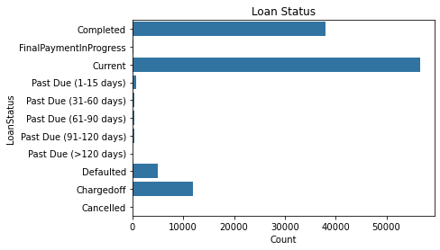

## Distribution of homeownership

Home ownership is roughly split evenly with slightly more homeowners than non-homeowners.

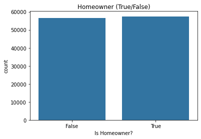

## Distribution of monthly income

As usual monthly income is positively skewed so note the log scale on the x-axis. The median monthly income is around 5k, but can vary to over 1 million.

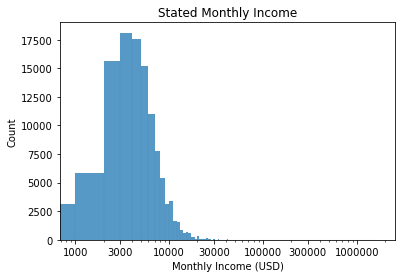

## Stated Monthly Income vs Loan Status

Having a higher monthly income means one is more likely to be in good standing. Note the log scale on the y-axis.

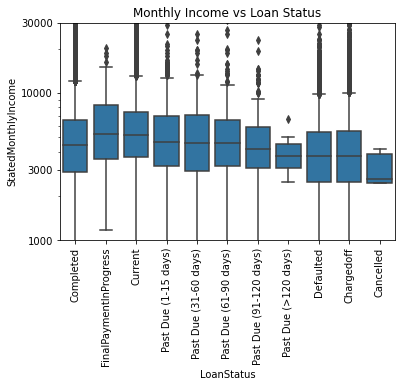

## Homeownership vs Loan Status

These proportions are normalized by the number of homeowners vs non-homeowners. Default, chargedoff or cancelled loans are more common with non-homeowners.

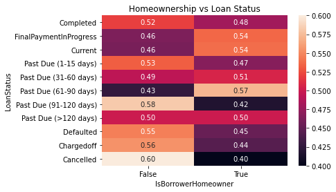

## Looking at 3 variables, Homeownership, Monthly Income, and Loan Status

One can see that the homeowner status of the borrower does not affect the relationship between income and loan status.

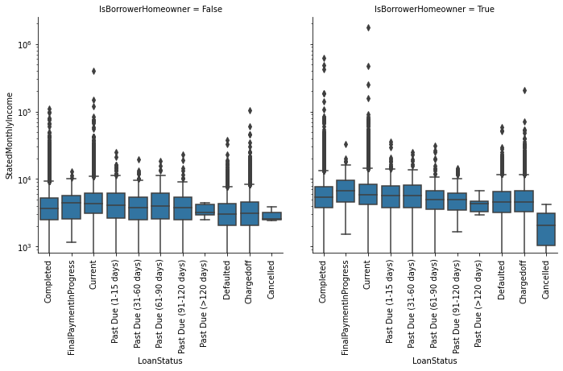